# Power of Random Forest in Business

SSI Data Explore

Author

Stutti (Advisor: Dr. Seals)

Published

October 6, 2024

## SSI Sales Dataset Summary

The source data contains sales transactions for a span of 48 months and comes from SSI, a Florida based B2B2C type company. The company offers custom packaging in the food industry. It offers custom branding and design as well as actual supply of the products. Customers may have transactional based sales where each order serves as it’s own agreement or customers may have a long term contract where they agree to purchase a product or several products through the course of a six month period or a year, for example. Once these agreements are established, the customer instructs it’s distributor to purchase from SSI and deliver to them. So, the purchase order, in reality comes from this distributor and not the end client.

## Data Dictionary

| Attribute | Format | Description |
| --- | --- | --- |
| OPCO | Varchar | The customer placing the order. In this case, typically a Distributor. |
| SalesOrderID | Varchar | Unique identifier assigned to each sales order. |
| CustomerPO | Varchar | Customer’s unique identifier of their order sent to SSI |
| Product | Varchar | Unique identifier assigned to each product. |
| Description | Varchar | Description of the product being sold. |
| Substrate | Varchar | Type of product/material. |
| RequestedDeliveryDate | Varchar | Date the delivery was scheduled originally. |
| DateFulfilled | Varchar | Date the delivery was made. |
| qtyOrdered | Numeric | Quantity ordered on the order. |
| qtyFulfilled | Numeric | Quantity delivered on the order. |
| UnitPrice | Numeric | Price of each case of product SSI charges the customer. |
| TotalPrice | Numeric | Total price of the sales order. |
| Class | Varchar | Customer name |
| ShipToName | Varchar | Address name of ordering party |
| ShipToAddress | Varchar | Address where order needs to be delivered |
| SalesOrderStatus | Varchar | Status of Sales order |
| SalesItemStatus | Varchar | Status of each line item on the sales order |

## Table 1 - SSI Sales Data

[output not shown]

### Data Descriptions - Summary

```
     OPCO           SalesOrderID        CustomerPO          Product
 Length:32071       Length:32071       Length:32071       Length:32071
 Class :character   Class :character   Class :character   Class :character
 Mode  :character   Mode  :character   Mode  :character   Mode  :character



 Description         Substrate         RequestedDeliveryDate DateFulfilled
 Length:32071       Length:32071       Length:32071          Length:32071
 Class :character   Class :character   Class :character      Class :character
 Mode  :character   Mode  :character   Mode  :character      Mode  :character



   qtyOrdered       QuantityFulfilled   UnitPrice           TotalPrice
 Min.   :    1.00   Min.   :    1.0   Min.   :    0.164   Min.   :     4.0
 1st Qu.:    7.00   1st Qu.:    7.0   1st Qu.:   39.240   1st Qu.:   437.7
 Median :   24.00   Median :   24.0   Median :   58.220   Median :  1286.1
 Mean   :   61.47   Mean   :   60.9   Mean   :  107.911   Mean   :  3237.4
 3rd Qu.:   54.00   3rd Qu.:   54.0   3rd Qu.:   76.825   3rd Qu.:  3062.9
 Max.   :23160.00   Max.   :23160.0   Max.   :20283.460   Max.   :143084.7
    Class            ShipToName        ShipToAddress      SalesOrderStatus
 Length:32071       Length:32071       Length:32071       Length:32071
 Class :character   Class :character   Class :character   Class :character
 Mode  :character   Mode  :character   Mode  :character   Mode  :character



 SalesItemStatus
 Length:32071
 Class :character
 Mode  :character
```

### Data Descriptions - Glimpse

```
Rows: 32,071
Columns: 17
$ OPCO                  <chr> ".Sysco - Riverside", ".Sysco - Riverside", ".Sy…
$ SalesOrderID          <chr> "25897", "25897", "25843", "25855", "REC-25794",…
$ CustomerPO            <chr> "10268630", "10268630", "6939630", "28970150", "…
$ Product               <chr> "Bellus 460290", "Bellus 433470", "BBB-PLCC20-01…
$ Description           <chr> "Bagasse bowl lid  domestic 24oz-32oz", "Bagasse…
$ Substrate             <chr> "other", "bagasse", "plastic", "plastic", "plast…
$ RequestedDeliveryDate <chr> "9/26/24", "9/26/24", "9/18/24", "9/19/24", "8/2…
$ DateFulfilled         <chr> "9/17/24", "9/17/24", "9/17/24", "9/17/24", "9/1…
$ qtyOrdered            <dbl> 12, 12, 30, 24, 64, 360, 50, 24, 40, 36, 96, 72,…
$ QuantityFulfilled     <dbl> 12, 12, 6, 15, 64, 360, 50, 24, 40, 36, 96, 72, …
$ UnitPrice             <dbl> 38.79, 32.94, 56.99, 44.04, 44.25, 56.03, 25.86,…
$ TotalPrice            <dbl> 465.48, 395.28, 341.94, 660.60, 2832.00, 20170.8…
$ Class                 <chr> "Bowl Bliss", "Bowl Bliss", "Bowl Bliss", "Smoot…
$ ShipToName            <chr> ".Sysco Riverside", ".Sysco Riverside", ".Sysco …
$ ShipToAddress         <chr> "15750 Meridian Pkwy, Riverside, CA", "15750 Mer…
$ SalesOrderStatus      <chr> "Fulfilled", "Fulfilled", "Closed Short", "Close…
$ SalesItemStatus       <chr> "Fulfilled", "Fulfilled", "Closed Short", "Close…
```

### Data Descriptions - Describe

```
                       vars     n    mean      sd  median trimmed     mad  min
OPCO*                     1 32071  370.74  139.19  388.00  384.38   66.72 1.00
SalesOrderID*             2 32071 3752.78 2066.37 3700.00 3748.70 2523.39 1.00
CustomerPO*               3 28706 2804.29 1580.07 2624.50 2735.39 1664.96 1.00
Product*                  4 32071  267.06  133.72  253.00  269.68  152.71 1.00
Description*              5 32071  342.33  190.02  411.00  351.82  228.32 1.00
Substrate*                6 31601    7.12    1.38    7.00    7.43    1.48 1.00
RequestedDeliveryDate*    7 32071  556.95  298.53  586.00  562.98  386.96 1.00
DateFulfilled*            8 32071  482.04  259.27  503.00  486.79  332.10 1.00
qtyOrdered                9 32071   61.46  192.58   24.00   32.20   29.65 1.00
QuantityFulfilled        10 32071   60.90  191.53   24.00   32.02   29.65 1.00
UnitPrice                11 32071  107.91  406.66   58.22   58.46   28.08 0.16
TotalPrice               12 32071 3237.39 6482.45 1286.12 1782.00 1518.00 4.00
Class*                   13 32071   25.95   10.38   30.00   27.67    7.41 1.00
ShipToName*              14 32061  532.47  200.86  546.00  547.15  108.23 1.00
ShipToAddress*           15 32071  487.71  300.98  470.00  486.65  367.68 1.00
SalesOrderStatus*        16 32071    1.79    0.41    2.00    1.87    0.00 1.00
SalesItemStatus*         17 32071    1.99    0.09    2.00    2.00    0.00 1.00
                             max    range   skew kurtosis    se
OPCO*                     633.00    632.0  -0.91     0.54  0.78
SalesOrderID*            7585.00   7584.0   0.03    -1.06 11.54
CustomerPO*              6065.00   6064.0   0.32    -0.87  9.33
Product*                  487.00    486.0   0.06    -1.16  0.75
Description*              631.00    630.0  -0.38    -1.16  1.06
Substrate*                  8.00      7.0  -2.80     8.33  0.01
RequestedDeliveryDate*   1055.00   1054.0  -0.16    -1.17  1.67
DateFulfilled*            912.00    911.0  -0.14    -1.16  1.45
qtyOrdered              23160.00  23159.0  62.86  6905.83  1.08
QuantityFulfilled       23160.00  23159.0  63.84  7058.58  1.07
UnitPrice               20283.46  20283.3  14.52   331.50  2.27
TotalPrice             143084.74 143080.7   5.23    41.54 36.20
Class*                     40.00     39.0  -1.20     0.15  0.06
ShipToName*               930.00    929.0  -0.65     0.34  1.12
ShipToAddress*           1026.00   1025.0   0.09    -1.19  1.68
SalesOrderStatus*           2.00      1.0  -1.45     0.09  0.00
SalesItemStatus*            2.00      1.0 -11.40   128.07  0.00
```

### Data Descriptions - Snapshot of the data

| OPCO | SalesOrderID | CustomerPO | Product | Description | Substrate | RequestedDeliveryDate | DateFulfilled | qtyOrdered | QuantityFulfilled | UnitPrice | TotalPrice | Class | ShipToName | ShipToAddress | SalesOrderStatus | SalesItemStatus |
| --- | --- | --- | --- | --- | --- | --- | --- | --- | --- | --- | --- | --- | --- | --- | --- | --- |
| .Sysco - Riverside | 25897 | 10268630 | Bellus 460290 | Bagasse bowl lid domestic 24oz-32oz | other | 9/26/24 | 9/17/24 | 12 | 12 | 38.79 | 465.48 | Bowl Bliss | .Sysco Riverside | 15750 Meridian Pkwy, Riverside, CA | Fulfilled | Fulfilled |
| .Sysco - Riverside | 25897 | 10268630 | Bellus 433470 | Bagasse Bowl 32oz | bagasse | 9/26/24 | 9/17/24 | 12 | 12 | 32.94 | 395.28 | Bowl Bliss | .Sysco Riverside | 15750 Meridian Pkwy, Riverside, CA | Fulfilled | Fulfilled |
| .Sysco - Central Illinois | 25843 | 6939630 | BBB-PLCC20-01 | Bowl Bliss 20oz PET Drink Cup | plastic | 9/18/24 | 9/17/24 | 30 | 6 | 56.99 | 341.94 | Bowl Bliss | .Sysco - Central Illinois | 1 Sysco Drive, Lincoln, IL | Closed Short | Closed Short |
| .Sysco - Detroit | 25855 | 28970150 | CMI-PCK-01 | CMI Plastic PS wrapped cutlery kit (fork spoon & knife) | plastic | 9/19/24 | 9/17/24 | 24 | 15 | 44.04 | 660.60 | Smoothie Island | .Sysco - Detroit | 41600 Van Born Rd, Canton, MI | Closed Short | Closed Short |
| .Sysco - North Texas | REC-25794 | 38214260 | CPS-PLCC32-02 | Philly Bite Plastic Drink Cup 32oz | plastic | 8/28/24 | 9/16/24 | 64 | 64 | 44.25 | 2832.00 | Philly Bite | .Sysco - North Texas | 800 Trinity Drive, Lewisville, TX | Fulfilled | Fulfilled |
| .GFS - Lithia Springs | 25812 | 4511788276 | CHI-DS-200-5M-BLK | DineLink’s BLACK 2oz Souffle Cup 5 000/ctn | plastic | 9/17/24 | 9/16/24 | 360 | 360 | 56.03 | 20170.80 | DineLink International | .GFS Lithia Springs | 1500 North River Road, Lithia Springs, GA | Fulfilled | Fulfilled |

# Data Visualization1

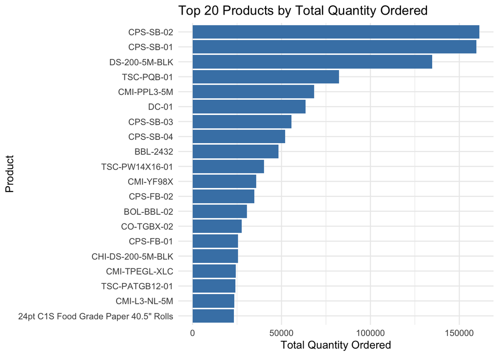

# Data Visualization2

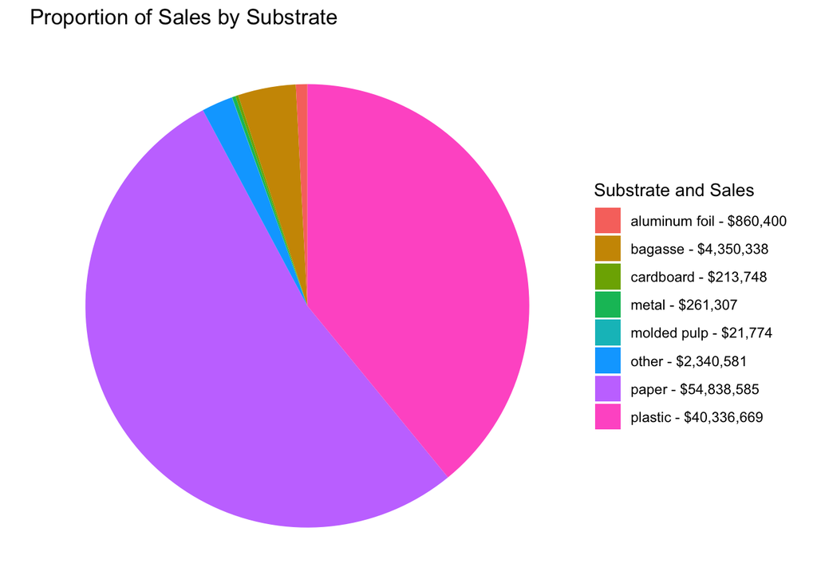

# Data Visualization3

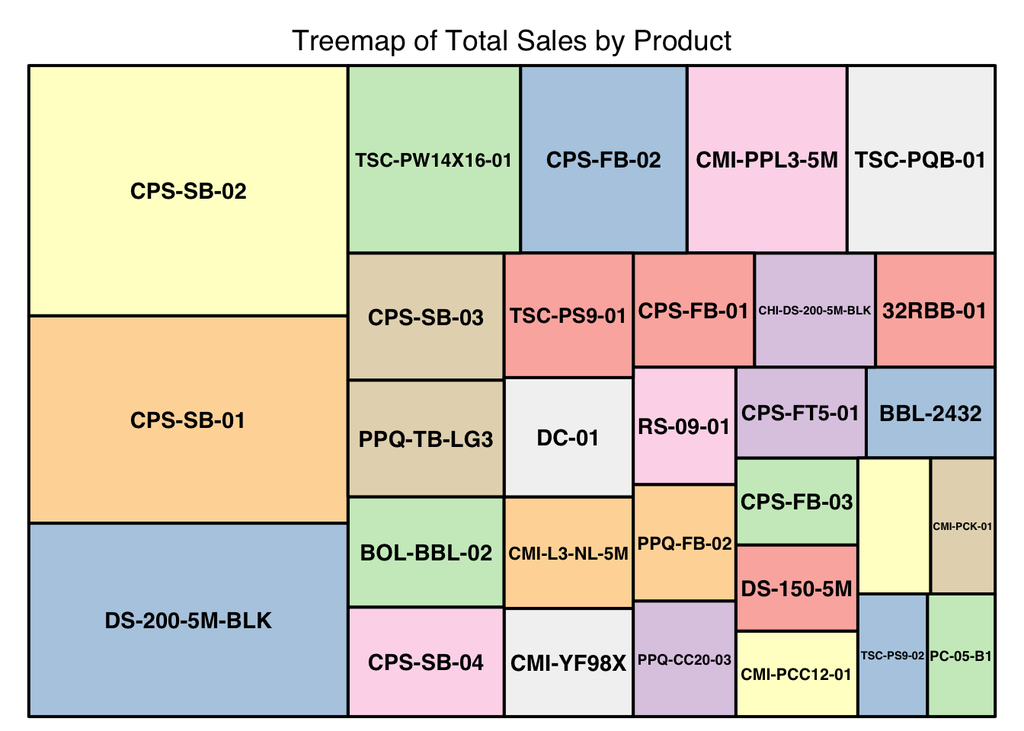

# Data Visualization4

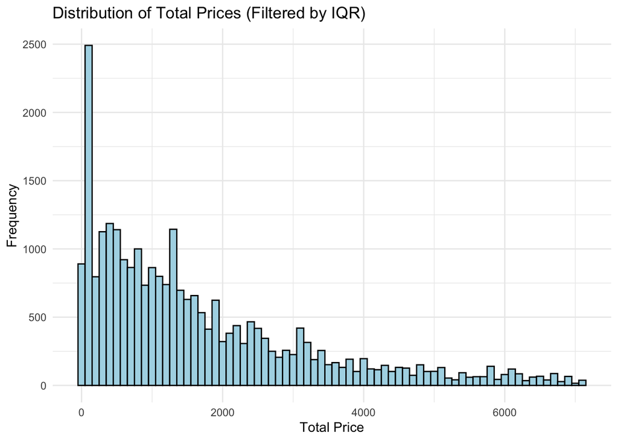

# Data Visualization5

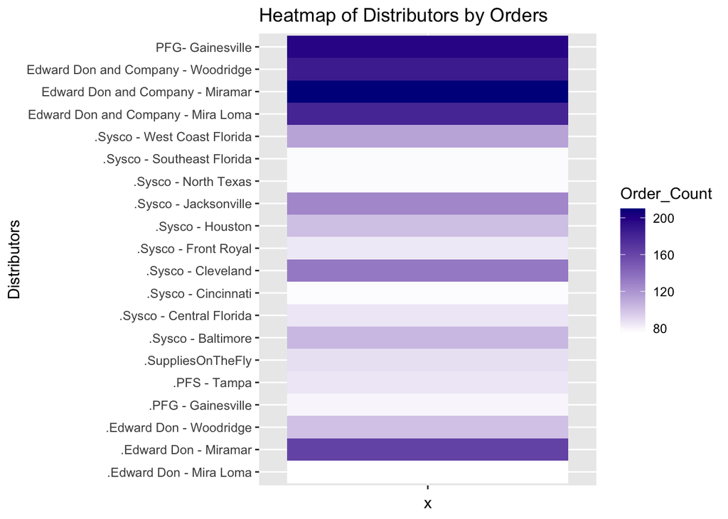

# Data Visualization6

[figure not shown]